# 1: Conceptos básicos sobre Algebra y Probabilidades

## Estudiante: Johnny Agüero Sandí

### Carné: 2020027766

## Primer parte - TEORÍA

### 1- Cuáles son las condiciones para que un sistema sea considerado como lineal?

Un sistema puede ser considerado como lineal si cumple con la propiedad de súper posición y homogeneidad, es decir si cumple con lo siguiente.

1. Superposición: La respuesta total a una combinación lineal de entradas es igual a la suma de las respuestas individuales a cada entrada por separado.

$$f(x + y) = f(x) + f(y)$$

2. Homogeneidad: La respuesta a una entrada escalada es igual a la entrada escalada de la respuesta.

$$f(ax) = af(x)$$

### 2- Por qué es conveniente modelar los problemas con sistemas lineales?

La modelización de problemas con sistemas lineales es conveniente por su simplicidad, generalidad, eficiencia computacional y la posibilidad de tener una interpretación física o intuitiva de las soluciones.

### 3- Qué es un tensor y cómo se relaciona con los vectores?

Un tensor es un objeto matemático que generaliza el concepto de vector en varias dimensiones. Se puede representar por un conjunto de números que se organizan en una estructura multilinear, es decir, una estructura que es lineal en cada una de sus variables. Los vectores son un caso especial de tensores, específicamente, son tensores de rango 1, lo que significa que son estructuras lineales que tienen una sola entrada o índice.

### 4- Cuál es la utilidad de la norma de Frobenius en Machine Learning?

La norma de Frobenius se utiliza como una penalización en técnicas de regularización como la regresión ridge. La inclusión de la norma de Frobenius en la función de pérdida ayuda a controlar el sobreajuste y a mejorar la generalización del modelo.

También la norma de Frobenius se utiliza en el cálculo de la descomposición en valores singulares (SVD) de una matriz.

Por otra parte la norma de Frobenius se utiliza como una medida de distancia entre dos matrices en algoritmos de optimización como el descenso de gradiente estocástico (SGD).

### 5- Cómo se puede interpretar una matriz en términos de vectores, refiérase a la linealidad?

Una matriz puede interpretarse en términos de vectores como una transformación lineal que mapea un vector de entrada en otro vector de salida, y la linealidad de la matriz se refleja en su aditividad y homogeneidad. Estas propiedades son fundamentales en la teoría de matrices y en aplicaciones prácticas de las mismas.

## Segunda parte - SISTEMAS LINEALES

### 1- Demuestre analíticamente si los siguientes sistemas son lineales o no lineales (Muestre todos los pasos). Considere a u(t) como la entrada del sistema, mientras que g(t) es la salida.

Para demostrar si una función es lineal o no, debemos verificar si cumple con las dos propiedades de la linealidad:

La propiedad de superposición: $$g(t_1 + t_2) = g(t_1) + g(t_2)$$

La propiedad de homogeneidad: $$g(\alpha t) = \alpha g(t)$$

### a) $g(t) = u(t)^2$

Propiedad de superposición:

$$g_1(t) = u_1(t)^2$$$$g_2(t) = u_2(t)^2$$$$g(t) = u(t)^2 = (u_1(t) + u_2(t))^2$$$$g(t) = u_1(t)^2 + 2u_1(t)u_2(t) + u_2(t)^2$$$$g(t) = g_1(t) + g_2(t) = u_1(t)^2 + u_2(t)^2$$$$u_1(t)^2 + u_2(t)^2 \neq u_1(t)^2 + 2u_1(t)u_2(t) + u_2(t)^2$$

Propiedad de homogeneidad:

$$g(t) = u(t)^2$$$$g(at) = (u(at))^2 = u(at)^2$$$$g(at) = u(at)^2 \neq ag(t) $$

Por lo tanto, $g(t) = u(t)^2 \textbf{ no es lineal.}$

### b) $g(t) = u(t^2)$

Propiedad de superposición:

$$g_1(t) = u_1(t^2)$$$$g_2(t) = u_2(t^2)$$$$g(t) = u(t^2) = u_1(t^2) + u_2(t^2)$$$$g(t) = g_1(t) + g_2(t) = u_1(t^2) + u_2(t^2)$$$$u_1(t^2) + u_2(t^2) = u_1(t^2) + u_2(t^2)$$

Propiedad de homogeneidad:

$$g(t) = u(t^2)$$$$g(at) = u((at)^2) = u(a^2t^2) = au(t^2)$$$$ag(t) = au(t^2) = g(at)$$

Por lo tanto, $g(t) = u(t^2) \textbf{ es lineal.}$

### c) $g(t) = u(t)sin(5t)$

Propiedad de superposición:

$$g_1(t) = u_1(t)sin(5t)$$$$g_2(t) = u_2(t)sin(5t)$$$$g(t) = (u_1(t) + u_2(t))sin(5t)$$$$g(t) = u_1(t)sin(5t) + u_2(t)sin(5t) = g_1(t) + g_2(t)$$

Propiedad de homogeneidad:

$$g(t) = u(t)sin(5t)$$$$g(at) = (au(t))sin(5at)$$$$g(at) = au(t)sin(5t) = ag(t)$$

Por lo tanto, $g(t) = u(t)sin(5t) \textbf{ es lineal.}$

### d) $g(t) = 5u(t)+6$

Propiedad de superposición:

$$g_1(t) = 5u_1(t)+6$$$$g_2(t) = 5u_2(t)+6$$$$g(t) = 5u(t) + 6 = 5(au_1(t) + u_2(t))+6$$$$g(t) = 5a_1(t) + 5a_2(t) + 6 $$

g_1(t) + g_2(t) = 5u_1(t) + 5u_2(t) + 12 \neq g(t)

Propiedad de homogeneidad:

$$g(t) = 5u(t)+6$$$$g(at) = 5(u(at))+6$$$$ag(t) = 5au(t)+6 \neq g(at)$$

Por lo tanto, $g(t) = 5u(t)+6 \textbf{ no es lineal.}$

### e) $g(t) = \int_{-\infty}^{\infty} u(t)$

Propiedad de superposición:

$$g_1(t) = \int_{-\infty}^{\infty} u_1(t)$$$$g_2(t) = \int_{-\infty}^{\infty} u_2(t)$$$$g(t) = \int_{-\infty}^{\infty} u(t) = \int_{-\infty}^{\infty} (u_1(t) + u_2(t))dt$$$$g(t) = \int_{-\infty}^{\infty} u_1(t)dt + \int_{-\infty}^{\infty} u_2(t)dt = g_1(t) + g_2(t)$$

Propiedad de homogeneidad:

$$g(t) = \int_{-\infty}^{\infty} u(t)$$$$g(t) = \int_{-\infty}^{\infty} u(t)dt$$$$g(kt) = \int_{-\infty}^{\infty} u(kt)dt$$$$g(kt) = \frac{1}{k}\int_{-\infty}^{\infty} u(s)ds = \frac{1}{k} g(t)$$

Por lo tanto, $g(t) = \int_{-\infty}^{\infty} u(t) \textbf{ es lineal}.$

### 2- Considere como base el código en Octave que se muestra en el listing 1, el cual realiza una comprobación sobre si un sistema es lineal o no. Verifique cada uno de los sistemas del punto anterior y compare el resultado con la demostración realizada en dicho punto (1). Además, grafique los resultados para observar el comportamiento de cada sistema y cual es el efecto de la escalación y superposición (Se desea obtener dos gráficas g y g3, según el código).

```python
# Listing 1
import numpy as np

t = np.arange(0, 6)
u1 = np.sin(t)
u2 = np.cos(t)
a = 5
b = 10
u = a*u1 + b*u2 # entrada del sistema au1(t) + bu2(t)
g = u # evaluacion del sistema con la entrada g(t) = u(t)
g1 = a*(u1)
g2 = b*(u2)
g3 = g1 + g2 # superposicion
result = np.round(g3 - g,0) # se redondea
if result.all() == 0: # si la resta es cero es porque son iguales
    print('Es un sistema lineal')
else:
    print('No es un sistema lineal')
```

```
Es un sistema lineal
```

### a) $g(t) = u(t)^2$

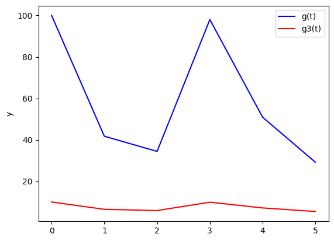

```
No es un sistema lineal
```

```python
# Listing 1
import numpy as np
import matplotlib.pyplot as plt

t = np.arange(0, 6)
u1 = np.power(np.sin(t),2)
u2 = np.power(np.cos(t),2)
a = 5
b = 10
u = a*u1 + b*u2 # entrada del sistema au1(t) + bu2(t)
g = np.power(u,2) # evaluacion del sistema con la entrada g(t) = u(t)
g1 = a*(u1)
g2 = b*(u2)
g3 = g1 + g2 # superposicion
result = np.round(g3 - g,0) # se redondea

plt.plot(t, g, color="blue", label="g(t)")
plt.plot(t, g3, color="red", label="g3(t)")
plt.legend(loc="upper right")
plt.xlabel("")
plt.ylabel("y")
plt.show()

if result.all() == 0: # si la resta es cero es porque son iguales
    print('Es un sistema lineal')
else:
    print('No es un sistema lineal')
```

### b) $g(t) = u(t^2)$

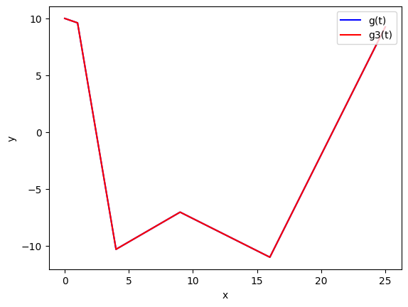

```
Es un sistema lineal
```

```python
# Listing 1
import numpy as np
import matplotlib.pyplot as plt

t = np.arange(0, 6)
t = np.power(t, 2)
u1 = np.sin(t)
u2 = np.cos(t)
a = 5
b = 10
u = a*u1 + b*u2 # entrada del sistema au1(t) + bu2(t)
g = u # evaluacion del sistema con la entrada g(t) = u(t)
g1 = a*(u1)
g2 = b*(u2)
g3 = g1 + g2 # superposicion
result = np.round(g3 - g,0) # se redondea

plt.plot(t, g, color="blue", label="g(t)")
plt.plot(t, g3, color="red", label="g3(t)")
plt.legend(loc="upper right")
plt.xlabel("x")
plt.ylabel("y")
plt.show()


if result.all() == 0: # si la resta es cero es porque son iguales
    print('Es un sistema lineal')
else:
    print('No es un sistema lineal')
```

### c) $g(t) = u(t)sin(5t)$

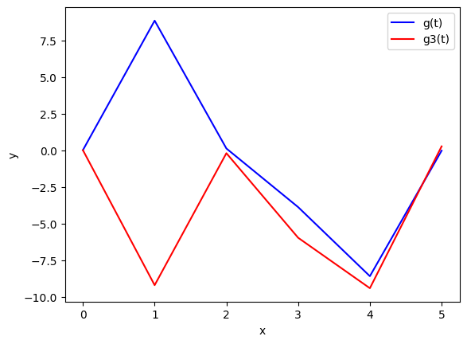

```
Es un sistema lineal
```

```python
# Listing 1
import numpy as np
import matplotlib.pyplot as plt

t = np.arange(0, 6)
u1 = np.sin(t)*np.sin(5*t)
u2 = np.cos(t)*np.sin(5*t)
a = 5
b = 10
u = a*u1 + b*u2 # entrada del sistema au1(t) + bu2(t)
g = u * np.sin(5*t) # evaluacion del sistema con la entrada g(t) = u(t)
g1 = a*(u1)
g2 = b*(u2)
g3 = g1 + g2 # superposicion
result = np.round(g3 - g,0) # se redondea

plt.plot(t, g, color="blue", label="g(t)")
plt.plot(t, g3, color="red", label="g3(t)")
plt.legend(loc="upper right")
plt.xlabel("x")
plt.ylabel("y")
plt.show()


if result.all() == 0: # si la resta es cero es porque son iguales
    print('Es un sistema lineal')
else:
    print('No es un sistema lineal')
```

### d) $g(t) = 5u(t)+6$

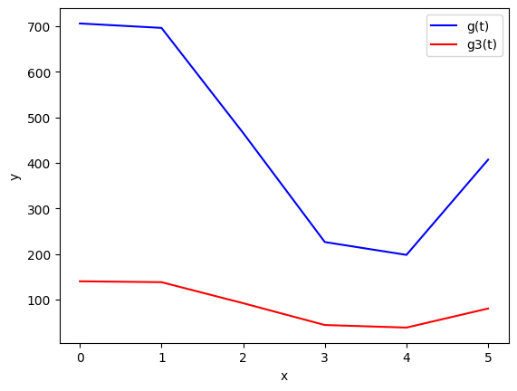

```
No es un sistema lineal
```

```python
# Listing 1
import numpy as np
import matplotlib.pyplot as plt

t = np.arange(0, 6)
u1 = 5 * np.sin(t) + 6
u2 = 5 * np.cos(t) + 6
a = 5
b = 10
u = a*u1 + b*u2 # entrada del sistema au1(t) + bu2(t)
g = 5 * u + 6 # evaluacion del sistema con la entrada g(t) = u(t)
g1 = a*(u1)
g2 = b*(u2)
g3 = g1 + g2 # superposicion
result = np.round(g3 - g,0) # se redondea

plt.plot(t, g, color="blue", label="g(t)")
plt.plot(t, g3, color="red", label="g3(t)")
plt.legend(loc="upper right")
plt.xlabel("x")
plt.ylabel("y")
plt.show()


if result.all() == 0: # si la resta es cero es porque son iguales
    print('Es un sistema lineal')
else:
    print('No es un sistema lineal')
```

### e) $g(t) = \int_{-\infty}^{\infty} u(t)$

```python
# Listing 1
from scipy.integrate import quad
import numpy as np
import matplotlib.pyplot as plt

t = np.arange(0, 6)
u1 = quad(np.sin(t), -np.inf, np.inf)
u2 = np.cos(t)
a = 5
b = 10
u = a*u1 + b*u2 # entrada del sistema au1(t) + bu2(t)
g = u # evaluacion del sistema con la entrada g(t) = u(t)
g1 = a*(u1)
g2 = b*(u2)
g3 = g1 + g2 # superposicion
result = np.round(g3 - g,0) # se redondea

plt.plot(t, g, color="blue", label="g(t)")
plt.plot(t, g3, color="red", label="g3(t)")
plt.legend(loc="upper right")
plt.xlabel("x")
plt.ylabel("y")
plt.show()


if result.all() == 0: # si la resta es cero es porque son iguales
    print('Es un sistema lineal')
else:
    print('No es un sistema lineal')
```

[output not shown]

### 3- Proponga dos sistemas diferentes al punto 1, tales que el primero sea lineal y el segundo no lo sea. Utilice el código anterior para demostrar la linealidad, además de las gráficas (similar al punto anterior).

### a) $g(t) = u(t)tan(t^2)$

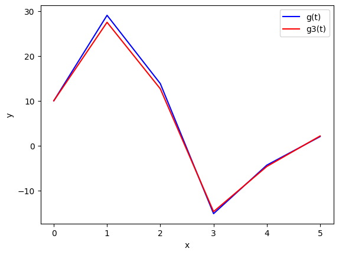

```
Es un sistema lineal
```

```python
# Listing 1
import numpy as np
import matplotlib.pyplot as plt

t = np.arange(0, 6)
u1 = np.sin(t) * np.tan(np.power(t,2))
u2 = np.cos(t) + np.tan(np.power(t,2))
a = 5
b = 10
u = a*u1 + b*u2 # entrada del sistema au1(t) + bu2(t)
g = u + np.tan(np.power(t,2)) # evaluacion del sistema con la entrada g(t) = u(t)
g1 = a*(u1)
g2 = b*(u2)
g3 = g1 + g2 # superposicion
result = np.round(g3 - g,0) # se redondea

plt.plot(t, g, color="blue", label="g(t)")
plt.plot(t, g3, color="red", label="g3(t)")
plt.legend(loc="upper right")
plt.xlabel("x")
plt.ylabel("y")
plt.show()


if result.all() == 0: # si la resta es cero es porque son iguales
    print('Es un sistema lineal')
else:
    print('No es un sistema lineal')
```

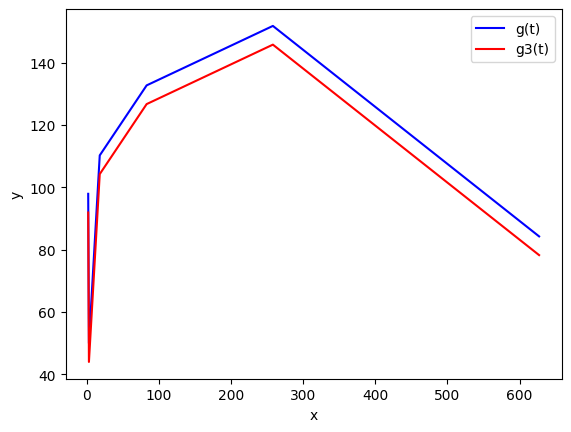

```
No es un sistema lineal
```

```python
# Listing 1
import numpy as np
import matplotlib.pyplot as plt

t = np.arange(0, 6)
t = np.power(t, 4) + 2
u1 = 5 * np.sin(t) + 6
u2 = 5 * np.cos(t) + 6
a = 5
b = 10
u = a*u1 + b*u2 # entrada del sistema au1(t) + bu2(t)
g = u + 6 # evaluacion del sistema con la entrada g(t) = u(t)
g1 = a*(u1)
g2 = b*(u2)
g3 = g1 + g2 # superposicion
result = np.round(g3 - g,0) # se redondea

plt.plot(t, g, color="blue", label="g(t)")
plt.plot(t, g3, color="red", label="g3(t)")
plt.legend(loc="upper right")
plt.xlabel("x")
plt.ylabel("y")
plt.show()


if result.all() == 0: # si la resta es cero es porque son iguales
    print('Es un sistema lineal')
else:
    print('No es un sistema lineal')
```

## Tercer parte - VECTORES

### 1- Demuestre que si dos vectores $\vec{x}$, $\vec{y}$ son paralelos, entonces se cumple $ \vec{x} = k\vec{y}, k ∈ R $

Para demostrar esto, podemos usar la definición de vectores paralelos, que establece que dos vectores son paralelos si tienen la misma dirección o son opuestos en dirección.

Si $\vec{x}$ y $\vec{y}$ tienen la misma dirección, entonces existe una constante $k$ positiva tal que $\vec{x} = k\vec{y}$, ya que ambos vectores apuntan en la misma dirección y la magnitud de $\vec{x}$ es $k$ veces la magnitud de $\vec{y}$.

Si $\vec{x}$ y $\vec{y}$ son opuestos en dirección, entonces existe una constante $k$ negativa tal que $\vec{x} = k\vec{y}$, ya que $\vec{x}$ y $\vec{y}$ apuntan en direcciones opuestas y la magnitud de $\vec{x}$ es igual a la magnitud de $\vec{y}$ multiplicada por un factor negativo.

Por lo tanto, en ambos casos, se cumple que $\vec{x} = k\vec{y}$ para alguna constante $k \in \mathbb{R}$, lo que demuestra que dos vectores paralelos pueden expresarse en términos de un múltiplo escalar.

### 2- Dado los vectores $\vec{x} = \left( \begin{array}{c} -9 \\ 3 \\ 5 \end{array} \right)$ , $\vec{y} = \left( \begin{array}{c} 3 \\ 0 \\ -11 \end{array} \right)$, encuentre de manera analítica el ángulo de separación, distancia $l_{2}$ y el vector unitario para cada uno de ellos.

El ángulo de separación entre los vectores $\vec{x}$ y $\vec{y}$, primero se debe calcular su producto punto y magnitudes:

$$ \vec{x} \cdot \vec{y} = (-9)(3) + (3)(0) + (5)(-11) = -27 - 55 = -82 $$$$ \vec{x} = \sqrt{(-9)^2 + 3^2 + 5^2} = \sqrt{115} $$$$ \vec{y} = \sqrt{3^2 + 0^2 + (-11)^2} = \sqrt{130} $$

Para encontrar la distancia $l_{2}$ entre los vectores $\vec{x}$ y $\vec{y}$, primero encontramos la diferencia entre los dos vectores:

$$ \vec{x} - \vec{y} = \left( \begin{array}{c} -9 \\ 3 \\ 5 \end{array} \right) - \left( \begin{array}{c} 3 \\ 0 \\ -11 \end{array} \right) = \left( \begin{array}{c} -12 \\ 3 \\ 16 \end{array} \right) $$

Por último dividimos cada vector por su norma para obtener el vector unitario correspondiente:

$$\hat{x} = \frac{\vec{x}}{|\vec{x}|} = \frac{1}{\sqrt{115}} \left( \begin{array}{c} -9 \\ 3 \\ 5 \end{array} \right) = \left( \begin{array}{c} -\frac{9}{\sqrt{115}} \\ \frac{3}{\sqrt{115}} \\ \frac{5}{\sqrt{115}} \end{array} \right)$$$$\hat{y} = \frac{\vec{y}}{|\vec{y}|} = \frac{1}{\sqrt{130}} \left( \begin{array}{c} 3 \\ 0 \\ -11 \end{array} \right) = \left( \begin{array}{c} \frac{3}{\sqrt{130}} \\ 0 \\ -\frac{11}{\sqrt{130}} \end{array} \right)$$

### 3- Grafique en Octave o Python en un solo gráfico ambos vectores.

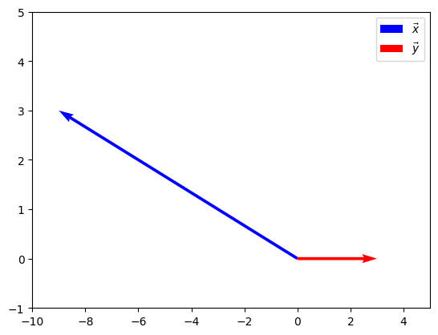

```python
import matplotlib.pyplot as plt
import numpy as np

x = np.array([-9, 3, 5])
y = np.array([3, 0, -11])

fig, ax = plt.subplots()

ax.quiver(0, 0, x[0], x[1], angles='xy', scale_units='xy', scale=1, color='blue', label=r'$\vec{x}$')
ax.quiver(0, 0, y[0], y[1], angles='xy', scale_units='xy', scale=1, color='red', label=r'$\vec{y}$')

ax.set_xlim([-10, 5])
ax.set_ylim([-1, 5])
ax.legend()

plt.show()
```

### 4- Obtenga la ecuación de un plano f, cuyo vector normal sea perpendicular a los vectores del puntos 2 (utilice producto X), además dicho plano contiene los puntos (3, 2, 6),(1, 2, 5).

Producto cruz de los vectores $\vec{x}$ y $\vec{y}$:

$$\vec{n} = \vec{x} \times \vec{y} = \left| \begin{array}{ccc} \vec{i} & \vec{j} & \vec{k} \\ -9 & 3 & 5 \\ 3 & 0 & -11 \end{array} \right| = \left( \begin{array}{c} -33 \\ -84 \\ -9 \end{array} \right) $$$$-33x - 84y - 9z = d$$

Sustituyendo las coordenadas del otro punto $(1,2,5)$:

$$-33(1) - 84(2) - 9(5) = d$$$$d = -246$$

Por lo tanto, la ecuación del plano $f$ es:

$$-33x - 84y - 9z = -246$$$$z = \frac{82}{3} - \frac{11x}{3} - \frac{28y}{3}$$

### 5- Grafique el plano del punto anterior junto con su vector normal (en una misma gráfica).

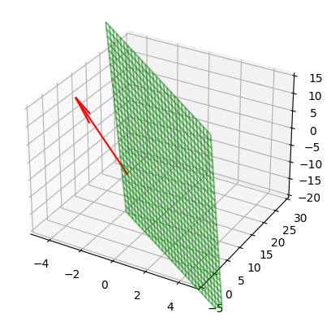

```python
import numpy as np
import matplotlib.pyplot as plt
from mpl_toolkits.mplot3d import Axes3D


def z(x, y):
    return (82/3) - (11*x/3) - (28*y/3)

x = np.linspace(-1, 5, 30)
y = np.linspace(-1, 5, 30)

X, Y = np.meshgrid(x, y)
Z = z(X,Y)

fig = plt.figure()
ax = plt.axes(projection ='3d')
ax.plot_wireframe(X, Y, Z, color ='green', alpha=0.5)

n = np.array([-33, 92, 9])
ax.quiver(0, 0, 0, n[0], n[1], n[2], color='red', length=0.2)

ax.set_xlim([-5, 5])
ax.set_ylim([-5, 30])
ax.set_zlim([-20, 15])

plt.show()
```

### 6- Calcule el vector gradiente del plano y evalúelo en el punto (3,3).

Definición del gradiente

$$\nabla f = \frac{\partial f}{\partial x} \hat{i} + \frac{\partial f}{\partial y} \hat{j} + \frac{\partial f}{\partial z} \hat{k}$$

## Cuarta parte - FUNCIONES MULTIVARIABLE

### 1- Para cada una de las siguientes funciones, grafique su superficie, calcule el vector gradiente de manera analítica, evalúelo en el punto que se solicita, además grafique dicho vector junto a la gráfica de superficie.

#### a) $z = f(x, y) = ln(x^{2} − y^{2})$, evalúe el gradiente en (−6, 1) y (4, −2)

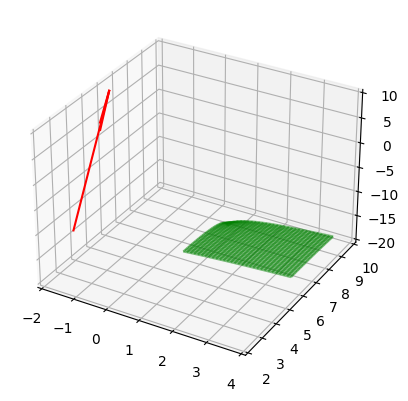

```python
import numpy as np
import matplotlib.pyplot as plt
from mpl_toolkits.mplot3d import Axes3D


def z(x, y):
    return np.log(x**2-y**2)

x = np.linspace(3.1, 6, 30)
y = np.linspace(0.1, 3, 30)

X, Y = np.meshgrid(x, y)
Z = z(X,Y)

fig = plt.figure()
ax = plt.axes(projection ='3d')
ax.plot_wireframe(X, Y, Z, color ='green', alpha=0.5)

n = np.array([2/3, 1/3])
ax.quiver(0, 0, 0, v[0], v[1], 0, color='red', length=0.1)

ax.set_xlim([-2, 4])
ax.set_ylim([2, 10])
ax.set_zlim([-20, 10])

plt.show()
```

#### b) $z = f(x, y) = e^{2x} + 3(y^{2} − 9)$, evalúe el gradiente en (0, 0) y (5, −5)

$$\frac{\partial z}{\partial x} = 2e^{2x} \text{ , } \frac{\partial z}{\partial y} = 6y$$$$\nabla f(x,y) = \begin{pmatrix} 2e^{2x} \\ 6y \end{pmatrix} $$$$\nabla f(0,0) = \begin{pmatrix} 2e^{2(0)} \\ 6(0) \end{pmatrix} = \begin{pmatrix} 2 \\ 0 \end{pmatrix} $$$$\nabla f(5,-5) = \begin{pmatrix} 2e^{2(5)} \\ 6(-5) \end{pmatrix} = \begin{pmatrix} 2e^{10} \\ -30 \end{pmatrix} $$

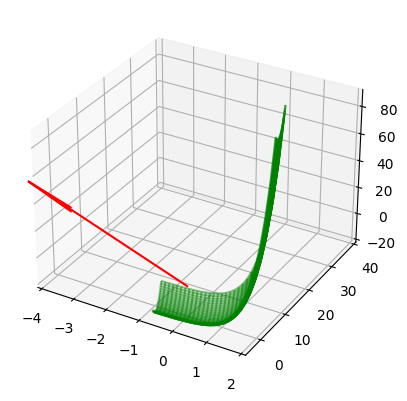

```python
import numpy as np
import matplotlib.pyplot as plt
from mpl_toolkits.mplot3d import Axes3D


def z(x, y):
    return np.exp(2*x)+3*(y**2-9)

x = np.linspace(-1, 2.5, 30)
y = np.linspace(-1, 2.5, 30)

X, Y = np.meshgrid(x, y)
Z = z(X,Y)

fig = plt.figure()
ax = plt.axes(projection ='3d')
ax.plot_wireframe(X, Y, Z, color ='green', alpha=0.5)

n = np.array([2*np.exp(10), -30])
ax.quiver(0, 0, 0, v[0], v[1], 0, color='red', length=0.2)

ax.set_xlim([-4, 2])
ax.set_ylim([-5, 40])
ax.set_zlim([-20, 90])

plt.show()
```

#### c) $z = f(x, y) = (y^{4} − x^{2}) − (x^{−2} + \sqrt{y})$, evalúe el gradiente en (1, 5) y (5, −1)

$$\frac{\partial z}{\partial x} = -2x + \frac{2}{x^3} \text{ , } \frac{\partial z}{\partial y} = 4y^3 - \frac{1}{2\sqrt{y}}$$$$\nabla f(x,y) = \begin{pmatrix} -2x + \frac{2}{x^3} \\ 4y^3 - \frac{1}{2\sqrt{y}} \end{pmatrix} $$$$\nabla f(1,5) = \begin{pmatrix} -2(1) + \frac{2}{1^3} \\ 4(5)^3 - \frac{1}{2\sqrt{5}} \end{pmatrix} = \begin{pmatrix} 0 \\ 499.77 \end{pmatrix} $$

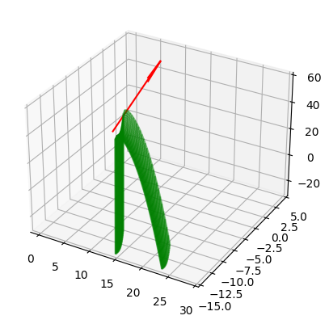

```python
import numpy as np
import matplotlib.pyplot as plt
from mpl_toolkits.mplot3d import Axes3D


def z(x, y):
    return (y**4 - x**2)-(x**(-2)+np.sqrt(y))

x = np.linspace(0.1, 10, 30)
y = np.linspace(0.1, 2, 30)

X, Y = np.meshgrid(x, y)
Z = z(X,Y)

fig = plt.figure()
ax = plt.axes(projection ='3d')
ax.plot_wireframe(X, Y, Z, color ='green', alpha=0.5)

n = np.array([0, 499])
ax.quiver(0, 0, 0, v[0], v[1], 0, color='red', length=0.2)

ax.set_xlim([-1, 30])
ax.set_ylim([-15, 5])
ax.set_zlim([-30, 60])

plt.show()
```

#### d) $z = f(x, y) = 4x^{3} − 5(y^{2} − x)^{2}$, evalúe el gradiente en (2, 2) y (3, −8)

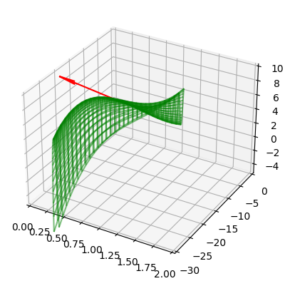

```python
import numpy as np
import matplotlib.pyplot as plt
from mpl_toolkits.mplot3d import Axes3D


def z(x, y):
    return 4*x**3-5*(y**2-x)**2

x = np.linspace(-1, 1, 30)
y = np.linspace(-1, 1, 30)

X, Y = np.meshgrid(x, y)
Z = z(X,Y)

fig = plt.figure()
ax = plt.axes(projection ='3d')
ax.plot_wireframe(X, Y, Z, color ='green', alpha=0.5)

n = np.array([76, -80])
ax.quiver(0, 0, 0, v[0], v[1], 0, color='red', length=0.03)

ax.set_xlim([0, 2])
ax.set_ylim([-30, 0])
ax.set_zlim([-5, 10])

plt.show()
```

## Quinta parte - MATRICES

### 1- Dada la matriz $ A = \left( \begin{matrix} 1 & 4 \\ -4 & -7 \\ \end{matrix} \right) $ calcule los eigen vectores y eigen valores de manera analítica, posteriormente utilice la función eig(A) para obtener la matriz de los autovalores y los auto vectores

Para calcular los eigen valores y eigen vectores de la matriz $A$, necesitamos resolver la ecuación característica:

$$\det(A - \lambda I) = 0$$

En este caso, la ecuación característica es:

$$\det \left( \begin{matrix} 1 - \lambda & 4 \\ -4 & -7 - \lambda \ \end{matrix} \right) = 0$$

Expandiendo esta determinante, obtenemos:

$$(1 - \lambda)(-7 - \lambda) - 4(-4) = \lambda^2 + 6\lambda + 9 = 0 $$

$$ (\lambda + 3)^2 = 0$$

$$\lambda_1 = -3 \text{, } \lambda_2 = -3$$

Para encontrar los eigen vectores correspondientes, debemos resolver el sistema de ecuaciones $(A - \lambda I) \mathbf{v} = \mathbf{0}$ para cada eigen valor.

Para $\lambda_1 = \lambda_2 = -3$, esto es:

$$\left( \begin{matrix} 1 - (-3) & 4 \\ -4 & -7 - (-3) \end{matrix} \right) \left( \begin{matrix} x \\ y \end{matrix} \right) = \left( \begin{matrix} 4 & 4 \\ -4 & -4 \end{matrix} \right) \left( \begin{matrix} x \\ y \end{matrix} \right) = \left( \begin{matrix} 0 \\ 0 \end{matrix} \right)$$$$\begin{align*} 4x + 4y &= 0 \\ -4x - 4y &= 0 \end{align*}$$

Los eigen vectores correspondientes a $\lambda_1 = \lambda_2 = -3$ son de la forma $\mathbf{v}_1 = \begin{pmatrix} -1 \\ 1 \end{pmatrix}$.

```python
import numpy as np


A = np.mat("1 4;-4 -7")


evalues, evectores = np.linalg.eig(A)

print(A)
print("")
print(evalues)
print("")
print(evectores)
```

```
[[ 1  4]
 [-4 -7]]

[-3.+5.96046448e-08j -3.-5.96046448e-08j]

[[ 0.70710678+0.00000000e+00j  0.70710678-0.00000000e+00j]
 [-0.70710678+1.05367121e-08j -0.70710678-1.05367121e-08j]]
```

## Sexta parte - PROBABILIDAD Y ESTADÍSTICA

### 1- Genere un set de datos aleatorio que consista en 4 variables $(h1, h2, h3, h4)$ con 20 muestras cada una. Muestre la matriz con las 20 muestras.

```python
import pandas as pd
import numpy as np

data = 4*np.random.rand(20, 4)

df = pd.DataFrame(data)

df.columns = ["h1", "h2", "h3", "h4"]
df.index = np.arange(1, len(df)+1)

print(df)
```

```
          h1        h2        h3        h4
1   1.093052  0.224095  0.381612  0.276231
2   2.176050  1.765662  3.822321  2.158011
3   1.803457  2.798580  0.889646  0.394522
4   2.524422  2.607745  0.291589  1.528457
5   3.817667  1.132659  3.518653  1.613141
6   2.323464  2.900865  1.294471  2.315459
7   3.189148  3.882774  1.211560  0.022711
8   0.049959  2.219184  3.888469  3.148362
9   0.040850  1.780315  3.140040  2.529446
10  2.540392  0.475544  2.518016  3.372730
11  0.098340  2.283846  3.616650  1.954964
12  3.829140  0.691967  3.479966  0.957947
13  3.899623  0.750900  2.818430  1.155961
14  1.255758  1.005051  1.868403  1.576856
15  1.601275  1.739976  1.318960  2.409320
16  1.191746  1.794488  0.582297  3.917343
17  3.401755  2.148010  1.677083  1.683956
18  3.390547  1.864566  0.735842  3.554177
19  0.978061  1.697199  0.103646  2.354729
20  2.233322  1.332338  0.551341  0.668664
```

### 2- Obtenga el valor esperado de cada una de las variables utilizando las funciones de Octave.

```python
mean_h1 = np.mean(data[:, 0])
mean_h2 = np.mean(data[:, 1])
mean_h3 = np.mean(data[:, 2])
mean_h4 = np.mean(data[:, 3])

print("Valor esperado de h1: ", mean_h1)
print("Valor esperado de h2: ", mean_h2)
print("Valor esperado de h3: ", mean_h3)
print("Valor esperado de h4: ", mean_h4)
```

```
Valor esperado de h1:  2.0719014242794356
Valor esperado de h2:  1.7547882187836994
Valor esperado de h3:  1.8854497207958842
Valor esperado de h4:  1.8796494125543919
```

### 3- Obtenga la matriz de covarianza sin utilizar la función. Puede utilizar la función cov

```python
data_centered = data - np.mean(data, axis=0)

cov_matrix = np.dot(data_centered.T, data_centered) / (data_centered.shape[0]-1)

print("Matriz de covarianza:\n", cov_matrix)
```

```
Matriz de covarianza:
 [[ 1.61860432 -0.10028335 -0.03545604 -0.39113077]
 [-0.10028335  0.81955039 -0.22832621 -0.07082837]
 [-0.03545604 -0.22832621  1.77637148  0.19834819]
 [-0.39113077 -0.07082837  0.19834819  1.23082095]]
```

### 4- Explique cuales de las variables se relacionan más y cuales se relacionan menos

En este caso, podemos observar que:

$1.$ La covarianza entre $h_1$ y $h_2$ es $-0.10028335$, lo que indica una relación negativa débil entre estas dos variables.

$2.$ La covarianza entre $h_1$ y $h_3$ es $-0.03545604$, lo que indica una relación débil o inexistente entre estas dos variables.

$3.$ La covarianza entre $h_1$ y $h_4$ es $-0.39113077$, lo que indica una relación negativa débil entre estas dos variables.

$4.$ La covarianza entre $h_2$ y $h_3$ es $-0.22832621$, lo que indica una relación negativa débil entre estas dos variables.

$5.$ La covarianza entre $h_2$ y $h_4$ es $-0.07082837$, lo que indica una relación negativa débil entre estas dos variables.

$6.$ La covarianza entre $h_3$ y $h_4$ es $0.19834819$, lo que indica una relación positiva débil entre estas dos variables.